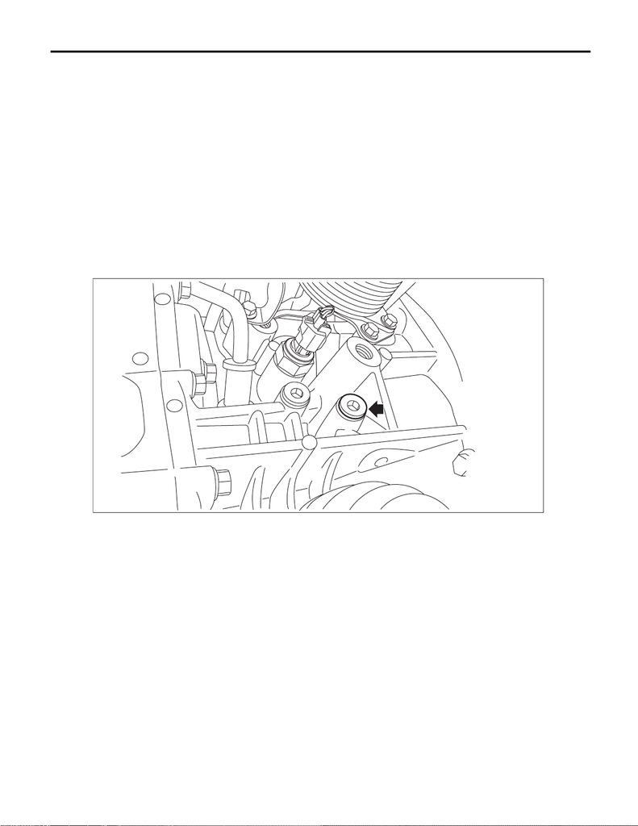

CVT(TR690)-49

Secondary Pressure (Line Pressure) Test

CONTINUOUSLY VARIABLE TRANSMISSION

8. Secondary Pressure (Line Pressure) Test

A: INSPECTION

CAUTION:

Make sure no other person is around the vehicle during secondary pressure (line pressure) test mea-

surement.

NOTE:

• If the pulley and variator chain, clutch or brake show signs of slipping or shift feel is not correct, check the

secondary pressure (line pressure).

• Connect Subaru Select Monitor to vehicle so as to measure the engine speed and actual secondary pres-

sure (secondary pressure (line pressure)).

• In many cases, slippage or inability to operate the vehicle may be due to insufficient oil pressure for the op-

eration of clutch, brake or control valve.

1) Remove the front wheel RH. <Ref. to WT-5, REMOVAL, Tire and Wheel.>

2) Lift up the vehicle.

3) Remove the test plug for secondary pressure (line pressure).

AT-07834

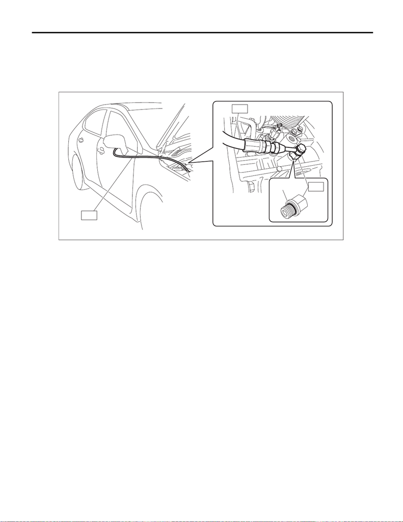

CVT(TR690)-50

Secondary Pressure (Line Pressure) Test

CONTINUOUSLY VARIABLE TRANSMISSION

4) Attach ST1, ST2 and ST3 to transmission.

ST1 18801AA000 OIL PRESSURE GAUGE ASSY

ST2 18681AA000 PRESSURE GAUGE ADAPTER

ST3 498897700 OIL PRESSURE ADAPTER SET

NOTE:

Use ST2 PRESSURE GAUGE ADAPTER with genuine O-ring (part No. 806911080) attached.

5) Set the gauge so that it can be seen from the driver’s seat.

6) Install the front wheel RH. <Ref. to WT-5, INSTALLATION, Tire and Wheel.>

7) Using the Subaru Select Monitor, check if the throttle valve operates when you depress the accelerator

pedal. <Ref. to EN(w/o STI)(diag)-37, DISPLAY CURRENT ENGINE DATA, OPERATION, Subaru Select

Monitor.>

8) Check the engine oil level. <Ref. to LU(w/o STI)-2, General Description.>

9) Check the coolant level. <Ref. to CO(w/o STI)-13, Engine Coolant.>

10) Adjust the CVTF level. <Ref. to CVT(TR690)-36, ADJUSTMENT, CVTF.>

11) Increase the CVTF temperature to 60 — 80°C (140 — 176°F) by idling the engine with the select lever

shifted to “N” or “P” range.

12) Shift the select lever to “D” range.

13) Depress the accelerator pedal to the full while fully depressing the foot brake pedal with your left foot.

(A) O-ring (genuine part)

CVT00488

ST1

(A)

ST2

ST3

[figure not shown]

CVT(TR690)-51

Secondary Pressure (Line Pressure) Test

CONTINUOUSLY VARIABLE TRANSMISSION

14) Immediately after the engine speed becomes steady, record the reading of the secondary pressure (line

pressure), engine speed and actual secondary pressure on Subaru Select Monitor. And then release the ac-

celerator pedal. Shift the select lever to “N” range. Let the engine idle for one minute or more to cool it down.

NOTE:

• Do not continue the stall test for 5 seconds or more at a time (from fully closed throttle, fully open throttle

to secondary pressure (line pressure) reading). Failure to follow this instruction will cause the engine oil and

CVTF to deteriorate and the clutch and brake to be adversely affected.

• After performing the secondary pressure (line pressure) test, be sure to cool down the engine for at least

one minute with the select lever set in “P” or “N” range and with the idle speed at 1,200 r/min or less.

• Under each condition, check that the measured pressure matches almost totally with actual secondary

pressure.

• When both measured pressure and actual secondary pressure are out of specification, judge as control

valve malfunction.

• The value at stall is for reference because the pressure changes under different conditions or circumstanc-

es.

• The value at idling is steady because it is not affected by any condition or circumstance.

15) Remove the ST and install the plug after measurement.

NOTE:

Use new O-rings.

Tightening torque:

25 N·m (2.5 kgf-m, 18.4 ft-lb)

Secondary pressure (line pressure) standard

Range Throttle Brake

Secondary pressure (line pressure)

(MPa (kgf/cm

2

, psi))

Stall D, R Full open ON 4.5 — 6 (45.9 — 61.2, 652 — 870)

Idling P, N Full closed OFF 0.5 — 1.5 (5.1 — 15.3, 72 — 218)